# Assignment 2: Spatial Analysis and Visualization

Healthcare Access and Equity in Pennsylvania

Author

Henry Yang

Published

October 12, 2025

## Assignment Overview

**Learning Objectives:** - Apply spatial operations to answer policy-relevant research questions - Integrate census demographic data with spatial analysis - Create publication-quality visualizations and maps - Work with spatial data from multiple sources - Communicate findings effectively for policy audiences

## Part 1: Healthcare Access for Vulnerable Populations

### Research Question

**Which Pennsylvania counties have the highest proportion of vulnerable populations (elderly + low-income) living far from hospitals?**

Your analysis should identify counties that should be priorities for healthcare investment and policy intervention.

### Required Analysis Steps

Complete the following analysis, documenting each step with code and brief explanations:

#### Step 1: Data Collection

Load the required spatial data: - Pennsylvania county boundaries - Pennsylvania hospitals (from lecture data) - Pennsylvania census tracts

**Your Task:**

```r
# Load required packages
library(sf)
library(ggplot2)
library(knitr)
library(tidyverse)
library(tidycensus)
library(tigris)
library(here)

# Load spatial data
pa_counties <- counties(state = "PA", cb = TRUE, progress = FALSE)
pa_tracts <- tracts(state = "PA", cb = TRUE, progress = FALSE)
hospitals <- st_read(here("data", "hospitals.geojson"), quiet = TRUE)

# Check that all data loaded correctly
nrow(pa_counties)
```

```
[1] 67
```

```r
nrow(pa_tracts)
```

```
[1] 3445
```

```r
nrow(hospitals)
```

```
[1] 223
```

**Questions to answer:** - How many hospitals are in your dataset? - 223 hospitals. - How many census tracts? - 3,445 tracts. - What coordinate reference system is each dataset in? - Counties and tracts are using NAD 83, hospitals are using WGS 84.

#### Step 2: Get Demographic Data

Use `tidycensus` to download tract-level demographic data for Pennsylvania.

**Required variables:** - Total population - Median household income - Population 65 years and over (you may need to sum multiple age categories)

**Your Task:**

```r
# Get demographic data from ACS
pa_acs_vars <- c(
  total_pop = "B01003_001",
  median_income = "B19013_001",
  age65_66_m = "B01001_020",
  age67_69_m = "B01001_021",
  age70_74_m = "B01001_022",
  age75_79_m = "B01001_023",
  age80_84_m = "B01001_024",
  age85_over_m = "B01001_025",
  age65_66_f = "B01001_044",
  age67_69_f = "B01001_045",
  age70_74_f = "B01001_046",
  age75_79_f = "B01001_047",
  age80_84_f = "B01001_048",
  age85_over_f = "B01001_049"
)

pa_acs <- get_acs(
  geography = "tract",
  variables = pa_acs_vars,
  state = "PA",
  year = 2022,
  survey = "acs5",
  output = "wide",
  progress = FALSE
)

pa_acs <- pa_acs %>%
  mutate(pop65plusE = age65_66_mE + age67_69_mE + age70_74_mE + age75_79_mE + age80_84_mE + age85_over_mE + age65_66_fE + age67_69_fE + age70_74_fE + age75_79_fE + age80_84_fE + age85_over_fE)

# Join to tract boundaries
pa_tracts_acs <- pa_tracts %>%
  left_join(
    pa_acs %>%
      select(GEOID, total_popE, median_incomeE, pop65plusE),
    by = "GEOID"
  )

sum(is.na(pa_tracts_acs$median_incomeE))
```

```
[1] 62
```

```r
median(pa_tracts_acs$median_incomeE, na.rm = TRUE)
```

```
[1] 70188
```

**Questions to answer:** - What year of ACS data are you using? - 2022. - How many tracts have missing income data? - 62. - What is the median income across all PA census tracts? - $70,188. —

#### Step 3: Define Vulnerable Populations

Identify census tracts with vulnerable populations based on TWO criteria: 1. Low median household income (choose an appropriate threshold) 2. Significant elderly population (choose an appropriate threshold)

**Your Task:**

```r
# Filter for vulnerable tracts based on your criteria
q1_income <- quantile(pa_tracts_acs$median_incomeE,
                      probs = 0.25, na.rm = TRUE)

income_thres <- 56000
elder_thres <- 0.20

pa_tracts_acs <- pa_tracts_acs %>%
  mutate(
    pct65plus = pop65plusE / total_popE
  )

vulnerable_tracts <- pa_tracts_acs %>%
  filter(
    median_incomeE < income_thres,
    pct65plus > elder_thres
  )

n_vulnerable <- nrow(vulnerable_tracts)
n_total <- nrow(pa_tracts_acs)
pct_vulnerable <- round(100 * n_vulnerable / n_total, 1)

n_vulnerable; pct_vulnerable
```

```
[1] 273
```

```
[1] 7.9
```

#### Step 4: Calculate Distance to Hospitals

For each vulnerable tract, calculate the distance to the nearest hospital.

**Your Task:**

```r
# Transform to appropriate projected CRS
hospitals_proj <- st_transform(hospitals, 3365)
pa_tracts_proj <- st_transform(pa_tracts_acs, 3365)

# Calculate distance from each tract centroid to nearest hospital
vulnerable_tracts_proj <- pa_tracts_proj %>%
  filter(median_incomeE < 56000, pop65plusE / total_popE > 0.2)

vulnerable_centroids <- st_centroid(vulnerable_tracts_proj)

dist_matrix <- st_distance(vulnerable_centroids, hospitals_proj)
nearest_ft <- apply(dist_matrix, 1, min)
nearest_mi <- as.numeric(nearest_ft) / 5280

vulnerable_tracts_proj <- vulnerable_tracts_proj %>%
  mutate(nearest_hospital_dist = nearest_mi)

avg_dist <- round(mean(nearest_mi, na.rm = TRUE), 1)
max_dist <- round(max(nearest_mi, na.rm = TRUE), 1)
n_far <- sum(nearest_mi > 15, na.rm = TRUE)

avg_dist; max_dist; n_far
```

```
[1] 4.5
```

```
[1] 25.6
```

```
[1] 14
```

**Requirements:** - Use an appropriate projected coordinate system for Pennsylvania - Calculate distances in miles - Explain why you chose your projection

**Questions to answer:** - Explain why you chose your projection - EPSG:3365 (NAD83(HARN) / Pennsylvania South (ftUS)), which is a state-specific projected CRS for Pennsylvania. This system is designed for accurate distance and area measurements within the state. - What is the average distance to the nearest hospital for vulnerable tracts? - 4.5 miles. - What is the maximum distance? - 25.6 miles. - How many vulnerable tracts are more than 15 miles from the nearest hospital? - 14.

#### Step 5: Identify Underserved Areas

Define “underserved” as vulnerable tracts that are more than 15 miles from the nearest hospital.

**Your Task:**

```r
# Create underserved variable
vulnerable_tracts_proj <- vulnerable_tracts_proj %>%
  mutate(underserved = nearest_hospital_dist > 15)

n_underserved <- sum(vulnerable_tracts_proj$underserved, na.rm = TRUE)
pct_underserved <- round(100 * n_underserved / n_vulnerable, 1)

n_underserved; pct_underserved
```

```
[1] 14
```

```
[1] 5.1
```

**Questions to answer:** - How many tracts are underserved? - 14. - What percentage of vulnerable tracts are underserved? - 5.1%. - Does this surprise you? Why or why not? - It is not very surprising, because Pennsylvania has many hospitals clustered in metropolitan regions like Philadelphia and Pittsburgh, so most vulnerable tracts still have relatively good proximity.

#### Step 6: Aggregate to County Level

Use spatial joins and aggregation to calculate county-level statistics about vulnerable populations and hospital access.

**Your Task:**

```r
# Spatial join tracts to counties
# Aggregate statistics by county
pa_counties_proj <- st_transform(pa_counties, 3365)

vul_counties <- pa_counties_proj %>%
  st_join(vulnerable_tracts_proj) %>%
  group_by(GEOID = GEOID.x, Name = NAMELSAD.x) %>%
  summarize(
    n_vulnerable = n(),
    n_underserved = sum(underserved, na.rm = TRUE),
    pct_underserved = round(100 * n_underserved / n_vulnerable, 1),
    avg_hospital_dist = mean(nearest_hospital_dist, na.rm = TRUE),
    total_vul_pop = sum(total_popE, na.rm = TRUE)
  )

top5_pct_underserved <- vul_counties %>%
  ungroup() %>%
  arrange(desc(pct_underserved)) %>%
  slice(1:5)

top_vul_pop <- vul_counties %>%
  ungroup() %>%
  arrange(desc(total_vul_pop)) %>%
  slice(1:1)
```

**Required county-level statistics:** - Number of vulnerable tracts - Number of underserved tracts  
- Percentage of vulnerable tracts that are underserved - Average distance to nearest hospital for vulnerable tracts - Total vulnerable population

#### Step 7: Create Summary Table

Create a professional table showing the top 10 priority counties for healthcare investment.

**Your Task:**

```r
# Create and format priority counties table
priority_counties <- vul_counties %>%
  st_drop_geometry() %>%
  ungroup() %>%
  filter(pct_underserved >= 20) %>%
  arrange(desc(total_vul_pop)) %>%
  slice(1:10)  %>%
  select(
    County = Name,
    `# Vulnerable Tracts` = n_vulnerable,
    `# Underserved Tracts` = n_underserved,
    `% Underserved Tracts` = pct_underserved,
    `Avg. Distance to Hospital (mi)` = avg_hospital_dist,
    `Total Vulnerable Population` = total_vul_pop
  )

kable(
  priority_counties,
  caption = "Top 10 PA Counties for Prioritized Healthcare Investment (by vulnerable population in tracts ≥20% underserved, >15 miles from hospitals)",
  format.args = list(big.mark = ","),
  digits = 1
)
```

Top 10 PA Counties for Prioritized Healthcare Investment (by vulnerable population in tracts ≥20% underserved, >15 miles from hospitals)

[output not shown]

**Requirements:** - Use `knitr::kable()` or similar for formatting - Include descriptive column names - Format numbers appropriately (commas for population, percentages, etc.) - Add an informative caption - Sort by priority (you decide the metric)

## Part 2: Comprehensive Visualization

Using the skills from Week 3 (Data Visualization), create publication-quality maps and charts.

### Map 1: County-Level Choropleth

Create a choropleth map showing healthcare access challenges at the county level.

**Your Task:**

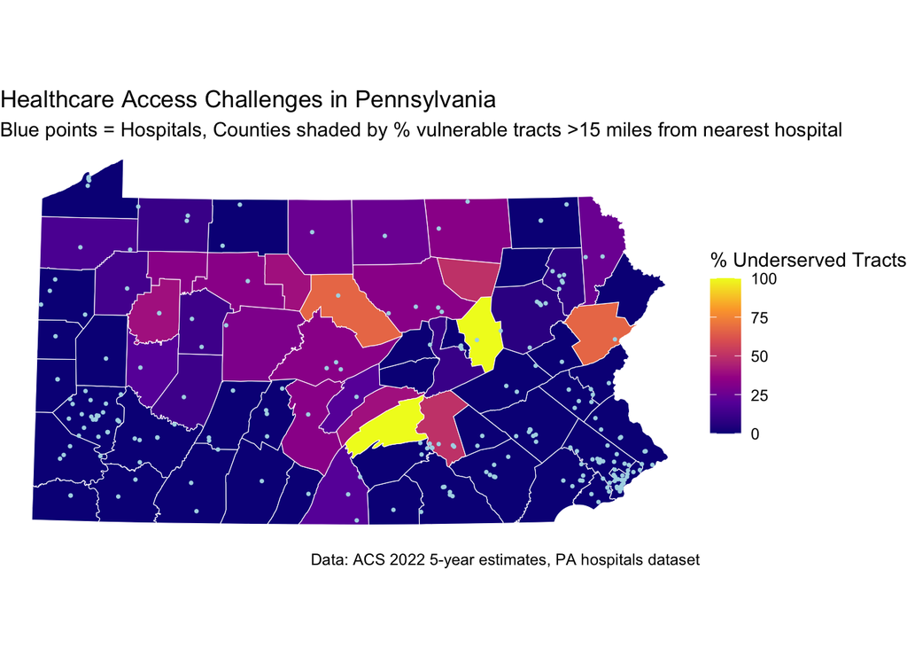

```r
# Create county-level access map
ggplot() +
  geom_sf(data = vul_counties, aes(fill = pct_underserved), color = "white", size = 0.5) +
  geom_sf(data = hospitals_proj, color = "lightblue", size = 0.5) +
  scale_fill_viridis_c(option = "plasma", name = "% Underserved Tracts") +
  labs(
    title = "Healthcare Access Challenges in Pennsylvania",
    subtitle = "Blue points = Hospitals, Counties shaded by % vulnerable tracts >15 miles from nearest hospital",
    caption = "Data: ACS 2022 5-year estimates, PA hospitals dataset"
  ) +
  theme_void()
```

**Requirements:** - Fill counties by percentage of vulnerable tracts that are underserved - Include hospital locations as points - Use an appropriate color scheme - Include clear title, subtitle, and caption - Use `theme_void()` or similar clean theme - Add a legend with formatted labels

### Map 2: Detailed Vulnerability Map

Create a map highlighting underserved vulnerable tracts.

**Your Task:**

[figure not shown]

```r
# Create detailed tract-level map
underserved_vul_tracts <- vulnerable_tracts_proj %>%
  filter(underserved)

ggplot() +
  geom_sf(data = pa_counties_proj, fill = "white", color = "grey", size = 0.5) +
  geom_sf(data = hospitals_proj, color = "red", size = 0.5) +
  geom_sf(data = underserved_vul_tracts, fill = "yellow", color = "grey", size = 0.5) +
  labs(
    title = "Healthcare Access Challenges in Pennsylvania",
    subtitle = "Blue points = Hospitals, Counties shaded by % vulnerable tracts >15 miles from nearest hospital",
    caption = "Data: ACS 2022 5-year estimates, PA hospitals dataset"
  ) +
  theme_void()
```

**Requirements:** - Show underserved vulnerable tracts in a contrasting color - Include county boundaries for context - Show hospital locations - Use appropriate visual hierarchy (what should stand out?) - Include informative title and subtitle

### Chart: Distribution Analysis

Create a visualization showing the distribution of distances to hospitals for vulnerable populations.

**Your Task:**

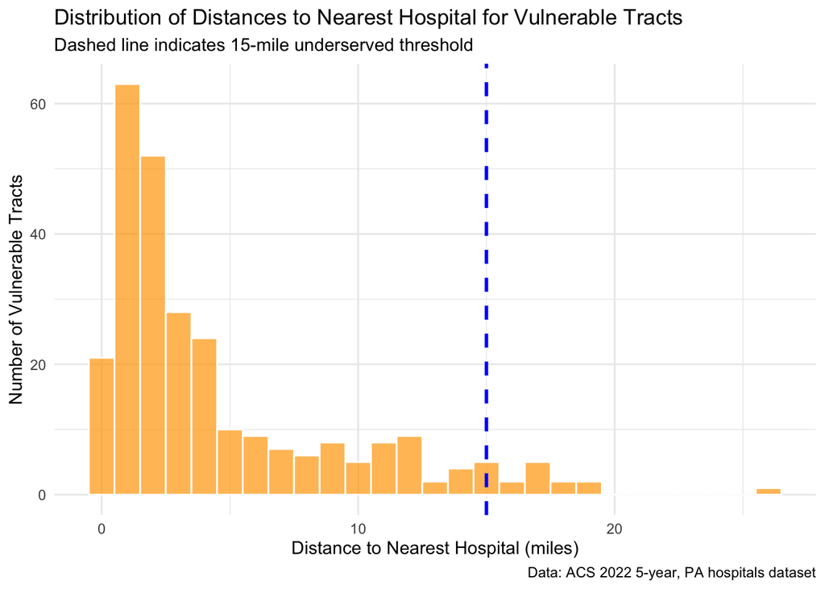

```r
# Create distribution visualization
ggplot(vulnerable_tracts_proj)+
  aes(x = nearest_hospital_dist) +
  geom_histogram(
    binwidth = 1,
    fill = "orange",
    color = "white",
    alpha = 0.7
  ) +
  geom_vline(aes(xintercept = 15), color = "blue", linetype = "dashed", size = 1) +
  labs(
    title = "Distribution of Distances to Nearest Hospital for Vulnerable Tracts",
    subtitle = "Dashed line indicates 15-mile underserved threshold",
    x = "Distance to Nearest Hospital (miles)",
    y = "Number of Vulnerable Tracts",
    caption = "Data: ACS 2022 5-year, PA hospitals dataset"
  ) +
  theme_minimal()
```

**Suggested chart types:** - Histogram or density plot of distances - Box plot comparing distances across regions - Bar chart of underserved tracts by county - Scatter plot of distance vs. vulnerable population size

**Requirements:** - Clear axes labels with units - Appropriate title - Professional formatting - Brief interpretation (1-2 sentences as a caption or in text)

## Part 3: Bring Your Own Data Analysis

Choose your own additional spatial dataset and conduct a supplementary analysis.

### Challenge Options

Choose ONE of the following challenge exercises, or propose your own research question using OpenDataPhilly data (https://opendataphilly.org/datasets/).

**Note these are just loose suggestions to spark ideas - follow or make your own as the data permits and as your ideas evolve. This analysis should include bringing in your own dataset, ensuring the projection/CRS of your layers align and are appropriate for the analysis (not lat/long or geodetic coordinate systems). The analysis portion should include some combination of spatial and attribute operations to answer a relatively straightforward question**

#### Education & Youth Services

**Option A: Educational Desert Analysis** - **Data:** Schools, Libraries, Recreation Centers, Census tracts (child population) - **Question:** “Which neighborhoods lack adequate educational infrastructure for children?” - **Operations:** Buffer schools/libraries (0.5 mile walking distance), identify coverage gaps, overlay with child population density - **Policy relevance:** School district planning, library placement, after-school program siting

**Option B: School Safety Zones** - **Data:** Schools, Crime Incidents, Bike Network - **Question:** “Are school zones safe for walking/biking, or are they crime hotspots?” - **Operations:** Buffer schools (1000ft safety zone), spatial join with crime incidents, assess bike infrastructure coverage - **Policy relevance:** Safe Routes to School programs, crossing guard placement

#### Environmental Justice

**Option C: Green Space Equity** - **Data:** Parks, Street Trees, Census tracts (race/income demographics) - **Question:** “Do low-income and minority neighborhoods have equitable access to green space?” - **Operations:** Buffer parks (10-minute walk = 0.5 mile), calculate tree canopy or park acreage per capita, compare by demographics - **Policy relevance:** Climate resilience, environmental justice, urban forestry investment —

#### Public Safety & Justice

**Option D: Crime & Community Resources** - **Data:** Crime Incidents, Recreation Centers, Libraries, Street Lights - **Question:** “Are high-crime areas underserved by community resources?” - **Operations:** Aggregate crime counts to census tracts or neighborhoods, count community resources per area, spatial correlation analysis - **Policy relevance:** Community investment, violence prevention strategies —

#### Infrastructure & Services

**Option E: Polling Place Accessibility** - **Data:** Polling Places, SEPTA stops, Census tracts (elderly population, disability rates) - **Question:** “Are polling places accessible for elderly and disabled voters?” - **Operations:** Buffer polling places and transit stops, identify vulnerable populations, find areas lacking access - **Policy relevance:** Voting rights, election infrastructure, ADA compliance

#### Health & Wellness

**Option F: Recreation & Population Health** - **Data:** Recreation Centers, Playgrounds, Parks, Census tracts (demographics) - **Question:** “Is lack of recreation access associated with vulnerable populations?” - **Operations:** Calculate recreation facilities per capita by neighborhood, buffer facilities for walking access, overlay with demographic indicators - **Policy relevance:** Public health investment, recreation programming, obesity prevention

#### Emergency Services

**Option G: EMS Response Coverage** - **Data:** Fire Stations, EMS stations, Population density, High-rise buildings - **Question:** “Are population-dense areas adequately covered by emergency services?” - **Operations:** Create service area buffers (5-minute drive = ~2 miles), assess population coverage, identify gaps in high-density areas - **Policy relevance:** Emergency preparedness, station siting decisions

#### Arts & Culture

**Option H: Cultural Asset Distribution** - **Data:** Public Art, Museums, Historic sites/markers, Neighborhoods - **Question:** “Do all neighborhoods have equitable access to cultural amenities?” - **Operations:** Count cultural assets per neighborhood, normalize by population, compare distribution across demographic groups - **Policy relevance:** Cultural equity, tourism, quality of life, neighborhood identity

### Data Sources

**OpenDataPhilly:** https://opendataphilly.org/datasets/ - Most datasets available as GeoJSON, Shapefile, or CSV with coordinates - Always check the Metadata for a data dictionary of the fields.

**Additional Sources:** - **Pennsylvania Open Data:** https://data.pa.gov/ - **Census Bureau (via tidycensus):** Demographics, economic indicators, commute patterns - **TIGER/Line (via tigris):** Geographic boundaries

### Recommended Starting Points

**If you’re feeling confident:** Choose an advanced challenge with multiple data layers. **If you are a beginner, choose something more manageable that helps you understand the basics**

**If you have a different idea:** Propose your own question! Just make sure: - You can access the spatial data - You can perform at least 2 spatial operations

### Your Analysis

**Your Task:**

1. **Find and load additional data**
   - Document your data source
   - Check and standardize the CRS
   - Provide basic summary statistics

```r
# Load your additional dataset
polling <- st_read(here("data", "polling_places.geojson"), quiet = TRUE)
bus <- st_read(here("data", "septa_bus.geojson"), quiet = TRUE)
metro <- st_read(here("data", "septa_metro.geojson"), quiet = TRUE)
rail <- st_read(here("data", "septa_rail.geojson"), quiet = TRUE)
trolley <- st_read(here("data", "septa_trolley.geojson"), quiet = TRUE)

phl_tracts <- tracts(state = "PA", county = "Philadelphia", cb = TRUE, progress = FALSE)

phl_acs_vars <- c(
  total_pop = "B01003_001",
  age65_66_m = "B01001_020",
  age67_69_m = "B01001_021",
  age70_74_m = "B01001_022",
  age75_79_m = "B01001_023",
  age80_84_m = "B01001_024",
  age85_over_m = "B01001_025",
  age65_66_f = "B01001_044",
  age67_69_f = "B01001_045",
  age70_74_f = "B01001_046",
  age75_79_f = "B01001_047",
  age80_84_f = "B01001_048",
  age85_over_f = "B01001_049",
  total_disab = "C18108_001",
  disabled_pop = "C18108_002"
)

phl_acs <- get_acs(
  geography = "tract",
  variables = phl_acs_vars,
  state = "PA",
  county = "Philadelphia",
  year = 2022,
  survey = "acs5",
  output = "wide",
  progress = FALSE
)

phl_acs <- phl_acs %>%
  mutate(
    pop65plusE = age65_66_mE + age67_69_mE + age70_74_mE + age75_79_mE +
                 age80_84_mE + age85_over_mE +
                 age65_66_fE + age67_69_fE + age70_74_fE + age75_79_fE +
                 age80_84_fE + age85_over_fE,
    pct_elderly = 100 * pop65plusE / total_popE,
    pct_disabled = 100 * disabled_popE / total_disabE
  )

phl_tracts_acs <- phl_tracts %>%
  left_join(phl_acs, by = "GEOID")

septa_stops <- bind_rows(
  bus %>% mutate(mode = "Bus"),
  metro %>% mutate(mode = "Metro"),
  rail %>% mutate(mode = "Regional Rail"),
  trolley %>% mutate(mode = "Trolley")
)

polling <- st_transform(polling, 3365, quiet = TRUE)
septa_stops <- st_transform(septa_stops, 3365, quiet = TRUE)
phl_tracts_acs <- st_transform(phl_tracts_acs, 3365, quiet = TRUE)

nrow(polling)
```

```
[1] 1703
```

```r
nrow(septa_stops)
```

```
[1] 18509
```

```r
nrow(phl_tracts_acs)
```

```
[1] 408
```

2. **Pose a research question**

Write a clear research statement that your analysis will answer.

** - Are polling places in Philadelphia County equitably accessible for elderly and disabled residents via public transit?**

**Examples:** - “Do vulnerable tracts have adequate public transit access to hospitals?” - “Are EMS stations appropriately located near vulnerable populations?” - “Do areas with low vehicle access have worse hospital access?”

3. **Conduct spatial analysis**

Use at least TWO spatial operations to answer your research question.

**Required operations (choose 2+):** - Buffers - Spatial joins - Spatial filtering with predicates - Distance calculations - Intersections or unions - Point-in-polygon aggregation

**Your Task:**

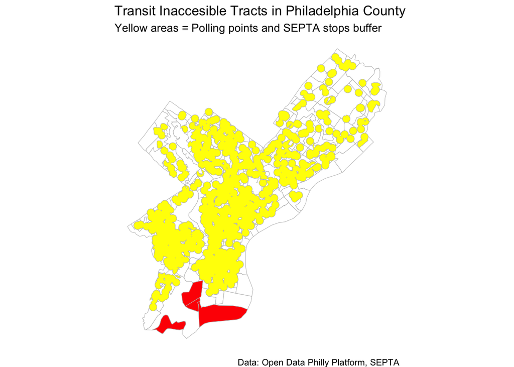

```r
# Your spatial analysis
polling_buf <- st_buffer(polling, dist = 1320)
stops_buf <- st_buffer(septa_stops, dist = 1320)
accessible_area <- st_intersection(polling_buf, stops_buf)

accessible_area_union <- accessible_area %>%
  st_union() %>%
  st_make_valid() %>%
  st_sf()

hit <- st_intersects(phl_tracts_acs, accessible_area_union, sparse = FALSE)[,1]

phl_tract_access <- phl_tracts_acs %>%
  mutate(accessible = hit)

phl_tract_summary <- phl_tract_access %>%
  st_drop_geometry() %>%
  group_by(accessible) %>%
  summarise(
    total_pop = sum(total_popE, na.rm = TRUE),
    elderly_pop = sum(pop65plusE, na.rm = TRUE),
    disabled_pop = sum(disabled_popE, na.rm = TRUE)
  )

inaccessible_tracts <- phl_tract_access %>%
  filter(accessible == FALSE)

ggplot() +
  geom_sf(data = phl_tract_access, fill = "white", color = "grey", size = 0.5) +
  geom_sf(data = inaccessible_tracts, fill = "red", color = "grey", size = 0.5) +
  geom_sf(data = accessible_area_union, fill = "yellow", color = "grey", size = 0.5) +
  labs(
    title = "Transit Inaccesible Tracts in Philadelphia County",
    subtitle = "Yellow areas = Polling points and SEPTA stops buffer",
    caption = "Data: Open Data Philly Platform, SEPTA"
  ) +
  theme_void()
```

**Analysis requirements:** - Clear code comments explaining each step - Appropriate CRS transformations - Summary statistics or counts - At least one map showing your findings - Brief interpretation of results (3-5 sentences)

**Your interpretation:**

The analysis used a 0.25-mile buffer to represent a reasonable walking distance for elderly and disabled residents to reach polling places and nearby transit stops. By intersecting the polling-place and transit buffers, I identified areas that are walkable from both a polling place and a transit stop. A spatial join with census tracts showed that nearly all residential tracts in Philadelphia are accessible, with only four non-residential tracts outside the buffer area. This indicates that Philadelphia’s dense urban layout and extensive SEPTA network provide strong transit-based access to polling places for vulnerable populations.

## Finally - A few comments about your incorporation of feedback!

After receiving feedback on my first assignment, I will make several improvements to this report, removing unnecessary instruction text and private key information, and keeping only the essential tables and visualizations to maintain a clear and focused narrative.